# Prediction Assignment Writeup- Practical Machine Learning

## Building the Random Forest Model

Using random forest, the out of sample error should be small. The error will be estimated using the 40% testing sample. We should expect an error estimate of < 3%

```r
set.seed(12345)

#need to convert the training classe to factor first so that randomForest can be run and to avoid fewer unique value
training$classe <- as.factor(training$classe)
modRF <- randomForest(classe ~ ., data = training, ntree = 1000, importance=TRUE)
```

### Plot for Random Forest Model

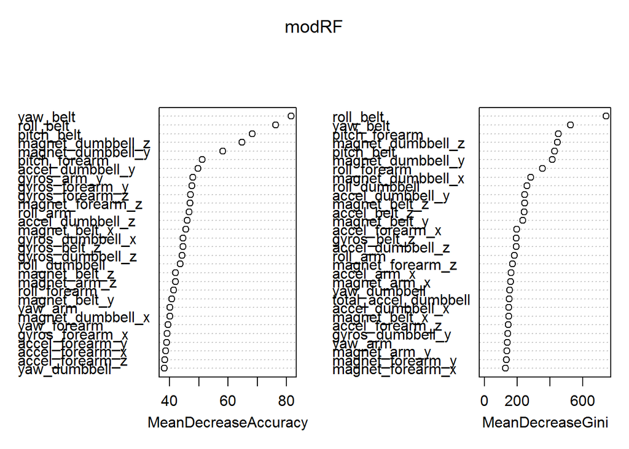

```r
varImpPlot(modRF, )
```

we can see which variables have higher impact on the prediction.

### Predict Random Forest Model

```r
predictionRFM <- predict(modRF, testing, type = "class")
confusionMatrix(predictionRFM, testing$classe)
```

```
## Confusion Matrix and Statistics
##
##           Reference
## Prediction    1    2    3    4    5
##          1 2205   20    0    0    0
##          2    1 1497    4    0    0
##          3    1    2 1388   14    2
##          4    0    0    1 1271    2
##          5    0    0    0    1 1438
##
## Overall Statistics
##
##                Accuracy : 0.9939
##                  95% CI : (0.9919, 0.9955)
##     No Information Rate : 0.2813
##     P-Value [Acc > NIR] : < 2.2e-16
##
##                   Kappa : 0.9923
##  Mcnemar's Test P-Value : NA
##
## Statistics by Class:
##
##                      Class: 1 Class: 2 Class: 3 Class: 4 Class: 5
## Sensitivity            0.9991   0.9855   0.9964   0.9883   0.9972
## Specificity            0.9965   0.9992   0.9971   0.9995   0.9998
## Pos Pred Value         0.9910   0.9967   0.9865   0.9976   0.9993
## Neg Pred Value         0.9996   0.9965   0.9992   0.9977   0.9994
## Prevalence             0.2813   0.1936   0.1775   0.1639   0.1838
## Detection Rate         0.2810   0.1908   0.1769   0.1620   0.1833
## Detection Prevalence   0.2835   0.1914   0.1793   0.1624   0.1834
## Balanced Accuracy      0.9978   0.9924   0.9967   0.9939   0.9985
```

Now lets evaluate this tree on the test data.

```r
tree.pred=predict(modRF,testing,type="class")
predMatrix = with(testing,table(tree.pred,classe))
sum(diag(predMatrix))/sum(as.vector(predMatrix)) # error rate
```

```
## [1] 0.993883
```

0.99 means we got a very accurate estimate.

# Conclusion

### Predicting on the Testing Data (pml-testing.csv)

### Decision Tree Prediction

```r
predictionDT <- predict(modDT, pmlTesting, type = "class")
predictionDT
```

```
##  1  2  3  4  5  6  7  8  9 10 11 12 13 14 15 16 17 18 19 20
##  3  1  3  4  4  3  4  4  1  1  2  3  5  1  5  4  1  1  1  2
## Levels: 1 2 3 4 5
```

### Random Forest Prediction

```r
predictionRF <- predict(modRF, pmlTesting, type = "class")
predictionRF
```

```
##  1  2  3  4  5  6  7  8  9 10 11 12 13 14 15 16 17 18 19 20
##  2  1  2  1  1  5  4  2  1  1  2  3  2  1  5  5  1  2  2  2
## Levels: 1 2 3 4 5
```

As can be seen from the confusion matrix the Random Forest model is very accurate, about 99%. Because of that we could expect nearly all of the submitted test cases to be correct. It turned out they were all correct.